# An Introduction to tseffects: Dynamic Inferences from Time Series (with Interactions)

Soren Jordan, Garrett N. Vande Kamp, and Reshi Rajan

2026-07-15

Autoregressive distributed lag (A[R]DL) models (and their reparameterized equivalent, the Generalized Error-Correction Model [GECM]) are the workhorse models in uncovering dynamic inferences. Since the introduction of the general-to-specific modeling strategy of Hendry (1995), users have become accustomed to specifying a single-equation model with (possibly) lags of the dependent variable included alongside the independent variables (in differences or levels, as appropriate) to capture dynamic inferences. Through all of the following, we assume users are familiar with such models and their best practices, including testing for stationarity on both sides of the equation (Philips 2022), equation balance (Pickup and Kellstedt 2023), the absence of serial autocorrelation in the residuals, or testing for moving averages (Vande Kamp and Jordan 2025). ADL models are simple to estimate; this is what makes them attractive. Once these models are estimated, what is less clear is how to uncover a rich set of dynamic *inferences* from these models. This complication arises in three key areas.

First: despite robust work on possible quantities of interest that can be derived from dynamic models (see De Boef and Keele (2008)), the actual calculation of these quantities (and corresponding measures of uncertainty) remains a considerable difficulty for practitioners. Formulae are often complex and model-dependent (i.e. on the underlying lag structure of the model), especially when considering periods other than an instantaneous effect or a long-run multiplier. While other, simulation-based methods exist to interpret A[R]DL models (as in Jordan and Philips (2018a)), these methods are not well equipped to test hypotheses of interest.

Second: methodological approaches to unbalanced equations or integrated series routinely involve differencing one or both sides of the ADL model to ensure stationarity. Yet researchers might wish to uncover inferences about their variables in levels, even if they are modeled in differences. Some work approaches this by generalizing shock histories to allow for inferences in levels or differences (Vande Kamp, Jordan, and Rajan (2025)), no implementation of this approach exists in software.

Third: the problem grows much more complicated when considering conditional dynamic relationships. Though recent work advances a unified modeling strategy through a general framework, including cross-lags (see Warner, Vande Kamp, and Jordan (2026)), no similar general approach exists to visualize interactive effects. This problem is complicated by the observation that, in any dynamic interactive model, time itself is a moderator that must be accounted for (Vande Kamp, Jordan, and Rajan (2022)) in addition to the values of both variables in the interaction (well established since Brambor, Clark, and Golder (**BramborClarkGolder2006?**)).

`tseffects` solves these problems. Our point of departure is leveraging Box, Jenkins, and Reinsel (1994). Rather than deriving period-specific and cumulative effects for every combination of independent variables, lags, and lags of the dependent variable (as in Wilkins (2018), for instance), or simulating the unfolding effects over time (as in Jordan and Philips (2018b)), Box, Jenkins, and Reinsel provide simple formulae that focus on the unique period-specific contribution of a change in an independent variable. To show how, we first re-introduce the ADL and GECM models and define typical effects calculated from these models. We then apply those effects to each of the unique problems outlined above.

# The ADL/GECM model

To help ensure consistency in notation, we define the ADL($p$,$q$) model as follows

$$Y_{t} = \alpha_{0} + \sum_{i = 1}^{p}\alpha_{i}Y_{t-i} + \sum_{j =
0}^{q}\beta_{j}X_{t-j} + \sum_{j = 0}^{q}\gamma_{j}Z_{t-j} + \sum_{k =
0}^{r}\theta_{k}\varepsilon_{t-k}$$

Similarly, we define its GECM equivalent as

$$\Delta Y_{t} = \alpha_{0} + \sum_{i = 1}^{p-1}\alpha_{i}\Delta
Y_{t-i} + \theta_{0}Y_{t-1} + \sum_{j = 0}^{q-1}\beta_{j}\Delta X_{t-j}
+ \theta_{1}X_{t-1} + \sum_{j = 0}^{q}\gamma_{j}Z_{t-j} + \sum_{k =
0}^{r}\theta_{k}\varepsilon_{t-k}$$

Notice in particular the form of the GECM with a single first lag of both the dependent and independent variable in levels. (The GECM calculations provided by `GDRF.gecm.plot` assume this correctly specified GECM and use the variable translations between the GECM and ADL to define the coefficient in ADL terms. These translations are done by `gecm.to.adl`.) The model might contain other regressors, but, for unconditional dynamic models, these regressors are unimportant for understanding the dynamic effects of variable $x$. We will use these models to define and recover time-series quantities of interest from the underlying model.

# A unified approach to inferences: the Generalized Dynamic Response Function

The ADL model is well established, and traditional quantities of interest are well known. Box, Jenkins, and Reinsel (1994) define quantities of interest that result from various shock histories applied to an independent variable. The first is the impulse response function (IRF) (or perhaps a short-run effect).

$$IRF_{s} = \beta_{s} +
\sum_{i=1}^{s}\alpha_{i}IRF_{s-i}$$

We additionally define the step response function (SRF), also referred to as a cumulative impulse response function in the time series literature.

$$SRF_{s} = \sum_{k=0}^{s}IRF_{k} =
IRF_{s} + SRF_{s-1}$$

These quantities are often estimated from an ADL including a dependent variable in levels or differences, an independent variable in levels or differences, or a mix of both. Yet scholars might want to make inferences regarding the dependent variable in levels *regardless* of its order of differencing in the ADL model. Or, scholars might want to uncover the effects of a shock history applied to an independent variable in levels, even if that independent variable is entered into the ADL in differences. Regular ADL formulae cannot deliver on this expectation. To resolve this deficiency, Vande Kamp, Jordan, and Rajan (2025) introduce the General Dynamic Response Function (GDRF)

$$\text{GDRF}_{s,h,d.y,d.x} \equiv
E[\Delta^{d.y}Y_{t+s}|\Delta^{d.x}X_{t:t+s}=\Delta^{d.x}x_{t:t+s}+c_{0:s,h},\textbf{Z}]
-E[\Delta^{d.y}Y_{t+s}|\Delta^{d.x}X_{t:t+s}=\Delta^{d.x}x_{t:t+s},
\textbf{Z}]$$
with the following elements:

- $d.y$: the number of times the dependent variable is differenced *before* determining the effect of the shock on the dependent variable. In other words, in the underlying model time series model, was the dependent variable first-differenced prior to estimation? If so, $d.y = 1$. If it is in levels, $d.y = 0$
- $d.x$: the number of times the independent variable is differenced *before* a shock is applied to it
- $s$: the number of time periods since a shock was applied

$h$ deserves special explanation. (Vande Kamp et al. 2025) demonstrate how the binomial function can be used to represent traditional and beyond-traditional shock histories typically examined in time series

- $h = 1$: Shock sequence $(1,2,3,4,\dots)$; Linear Trend Coefficient of $X$
- $h = 0$: Shock sequence $(1,1,1,1,\dots)$; Permanent One-Unit Increase (Step)
- $h = -1$: Shock sequence $(1,0,0,0,\dots)$ One-Time, One-Unit Increase (Pulse)

The second virtue of the binomial coefficient is that it translates between variables in levels and in differences. (Vande Kamp et al. 2025) demonstrate that an arbitrary shock history for a variable in levels is equivalent to another counterfactual shock history to that same variable after differencing, simply adjusting the parameter $h$:

$$\text{GDRF}_{s,h, d.y, 0} & \equiv
E[\Delta^{d.y}Y_{t+s}(\Delta^{d.x}(x_{1:t-1}), \Delta^{d.x}(x_{t:T} +
c_{0:T-t, h})) - \Delta^{d.y}Y_{t+s}(\Delta^{d.x}(x_{1:T}))] =
\text{GDRF}_{s,h-d.x, d.y, d.x}$$

So the GDRF “translates” these popular shock histories to recover inferences in the desired form of the independent and dependent variables, regardless of their modeled level of differencing, given the specified shock history. All scholars need to do is estimate the ADL model and choose a shock. The virtue of `tseffects` is that it automatically does this translation for you.

Computationally, the benefit of `tseffects` is that it applies these formulae symbolically. Rather than performing many recursive calculations as effects extend into future time periods, a symbolic representation of those formulae are built (using `mpoly`: (Kahle 2013)) that only need to be evaluated once. We can also peek “under the hood” at these formulae, perhaps as a teaching aid, to observe the GDRF in different periods, based on the model specified.

# Two subfunctions: `pulse.calculator` and `general.calculator`

While its unlikely that users will want to interact with these functions, they might be useful either for teaching or for developing a better understanding of the GDRF. Despite their names, neither function actually does any “calculation”; rather, they return an `mpoly` class of the formula that would be evaluated.

The first is `pulse.calculator`. Like its name implies, this calculates the traditional pulse effect for time period $s = 0$ up to $s = $ some `limit`. It returns a list of formulae, each one the pulse effect for the relevant period. (Time series scholars might refer to these as the period-specific effects.) It constructs these formulae given a named vector of the relevant $x$ variables (passed to `x.vrbl`) and their corresponding lag orders, as well as the same for $y$ (passed to `y.vrbl`), if given. Though most ADLs include a lagged dependent variable to allow for flexible dynamics, it is entirely possibly that a finite dynamic model is more appropriate: in this case, `y.vrbl` would be `NULL`.

Imagine a simple finite dynamic model, where the $x$ variables are `mood`, `l1.mood`, and `l2.mood` (lags need not be consecutive, though in a well-specified ADL they likely are). `pulse.calculator` would look like

```r
library(tseffects)
ADL.finite <- pulse.calculator(x.vrbl = c("mood" = 0, "l1_mood" = 1, "l2_mood" = 2),
               y.vrbl = NULL,
               limit = 5)
```

This list is six elements long: including the pulses for each period from 0 to 5. These will naturally be more complex if there are more sophisticated dynamics through a lagged dependent variable. For instance, if you estimate an ADL(1,2), where the $x$ variables are `mood`, `l1.mood`, and `l2.mood` and the dependent variable is `policy` (with its first lag `l1.policy`).

```r
ADL1.2.pulses <- pulse.calculator(x.vrbl = c("mood" = 0, "l1_mood" = 1, "l2_mood" = 2),
               y.vrbl = c("l1_policy" = 1),
               limit = 5)
```

These pulses form the basis of the GDRF, given the order of differencing of $x$ and $y$ and the specified shock history $h$. To create the formulae for the GDRF, `general.calculator` requires five arguments, most of which are defined above: `d.x` and `d.y` (defined with respect to the GDRF), `h` (the shock history applied), `limit`, and `pulses`. The novel argument, `pulses`, is the list of pulses for each period in which a GDRF is desired.

Assume the same ADL(1,2) from above. To recover the formulae for a GDRF of a pulse shock, assuming that both `mood` and `policy` are in levels (such that both `d.x` and `d.y` are 0), we would run

```r
general.calculator(d.x = 0, d.y = 0, h = -1, limit = 5, pulses = ADL1.2.pulses)
```

```
#> $formulae
#> $formulae[[1]]
#> [1] "mood "
#>
#> $formulae[[2]]
#> [1] "l1_mood  +  l1_policy * mood "
#>
#> $formulae[[3]]
#> [1] "l2_mood  +  l1_policy * l1_mood  +  l1_policy**2 * mood "
#>
#> $formulae[[4]]
#> [1] "l1_policy * l2_mood  +  l1_policy**2 * l1_mood  +  l1_policy**3 * mood "
#>
#> $formulae[[5]]
#> [1] "l1_policy**2 * l2_mood  +  l1_policy**3 * l1_mood  +  l1_policy**4 * mood "
#>
#> $formulae[[6]]
#> [1] "l1_policy**3 * l2_mood  +  l1_policy**4 * l1_mood  +  l1_policy**5 * mood "
#>
#>
#> $binomials
#> $binomials[[1]]
#> [1] 1
#>
#> $binomials[[2]]
#> [1] 1 0
#>
#> $binomials[[3]]
#> [1] 1 0 0
#>
#> $binomials[[4]]
#> [1] 1 0 0 0
#>
#> $binomials[[5]]
#> [1] 1 0 0 0 0
#>
#> $binomials[[6]]
#> [1] 1 0 0 0 0 0
```

(Since `general.calculator` is “under the hood,” `h` can only be specified as an integer. Later, in a more user-friendly function, we will see that shock histories can also be specified using characters.)

Recall that we might want to generalize our inferences beyond simple ADLs with both variables in levels. For exposition, assume that `mood` was integrated, so, to balance the ADL, it needed to be entered in differences. The user does this and enters $x$ variables as `d_mood`, `l1_d_mood`, and `l2_d_mood`. `pulse.calculator` would look like

```r
ADL1.2.d.pulses <- pulse.calculator(x.vrbl = c("d_mood" = 0, "l1_d_mood" = 1, "l2_d_mood" = 2),
               y.vrbl = c("l1_policy" = 1),
               limit = 5)
```

These pulses look identical to the ones from `ADL1.2.pulses`. But `tseffects` allows the user to recover inferences of a shock history applied to $x$ in levels, rather than its observed form of differences. All we need to do is specify the `d.x` order.

```r
general.calculator(d.x = 1, d.y = 0, h = -1, limit = 5, pulses = ADL1.2.d.pulses)
```

```
#> $formulae
#> $formulae[[1]]
#> [1] "d_mood "
#>
#> $formulae[[2]]
#> [1] "l1_d_mood  +  l1_policy * d_mood  -  d_mood "
#>
#> $formulae[[3]]
#> [1] "l2_d_mood  +  l1_policy * l1_d_mood  +  l1_policy**2 * d_mood  -  l1_d_mood  -  l1_policy * d_mood "
#>
#> $formulae[[4]]
#> [1] "l1_policy * l2_d_mood  +  l1_policy**2 * l1_d_mood  +  l1_policy**3 * d_mood  -  l2_d_mood  -  l1_policy * l1_d_mood  -  l1_policy**2 * d_mood "
#>
#> $formulae[[5]]
#> [1] "l1_policy**2 * l2_d_mood  +  l1_policy**3 * l1_d_mood  +  l1_policy**4 * d_mood  -  l1_policy * l2_d_mood  -  l1_policy**2 * l1_d_mood  -  l1_policy**3 * d_mood "
#>
#> $formulae[[6]]
#> [1] "l1_policy**3 * l2_d_mood  +  l1_policy**4 * l1_d_mood  +  l1_policy**5 * d_mood  -  l1_policy**2 * l2_d_mood  -  l1_policy**3 * l1_d_mood  -  l1_policy**4 * d_mood "
#>
#>
#> $binomials
#> $binomials[[1]]
#> [1] 1
#>
#> $binomials[[2]]
#> [1]  1 -1
#>
#> $binomials[[3]]
#> [1]  1 -1  0
#>
#> $binomials[[4]]
#> [1]  1 -1  0  0
#>
#> $binomials[[5]]
#> [1]  1 -1  0  0  0
#>
#> $binomials[[6]]
#> [1]  1 -1  0  0  0  0
```

As (Vande Kamp et al. 2025) suggest, scholars should be very thoughtful about the shock history applied. These shocks are applied to the underlying independent variable *in levels*. Since $x$ is integrated in this example, it might be more reasonable to imagine that the underlying levels variable is actually trending. To revise this expectation and apply a new shock history, we would run

```r
general.calculator(d.x = 1, d.y = 0, h = 1, limit = 5, pulses = ADL1.2.d.pulses)
```

[output not shown]

(Notice that the pulses do not change.) Recall that these are “under the hood”: we expect instead that most users will interact with the full calculation and plotting functions, discussed below.

# User-friendly effects: `GDRF.adl.plot` and `GDRF.gecm.plot`

Again, we expect most users will not interact with these calculators. Instead, they will estimate an ADL model via `lm` and expect easy-to-use effects. To achieve this directly, we introduce `GDRF.adl.plot`. We gloss over arguments that we’ve already seen in `pulse.calculator` and `general.calculator`:

- `x.vrbl`: a named vector of the $x$ variable and its lag orders
- `y.vrbl`: a named vector of the $y$ variable and its lag orders (if a lagged dependent variable is in the model)
- `d.x`: the order of differencing of the independent variable before a shock is applied
- `d.y`: the order of differencing of the dependent variable before effects are recovered
- `s.limit`: the number of periods for which to calculate the effects of the shock (the default is 20)

Now, since effects will be calculated, users must also provide a `model`: the `lm` object containing the (well-specified, balanced, free of serial autocorrelation, etc. ADL model) that has the estimates. Users must also specify a shock history through `shock.history`. Users can continue to specify an integer that represents `n` (from above) or can use the phrases `pulse` (for $h = -1$) and `step` (for $h = 0$).

Users have already indicated the order of differencing of $x$ and $y$ (through `d.x` and `d.y`): now `general.calculator` can leverage this information and the supplied `shock.history` to deliver inferences about $x$ in either levels or differences through `inferences.y` and `inferences.x`. If both $x$ and $y$ are entered into the ADL in levels (so that `d.x` and `d.y` are 0), `inferences.y` and `inferences.x` default to `levels`. If, however, either $x$ or $y$ (or both) are entered in differences, users can recover causal effects from a shock history applied to $x$ in levels, or to a dependent variable realized in levels. However, *they don’t have to*. The shock can still be applied to $x$ in differences, or the effects can be realized on $y$ in differences: just change `inferences.x` to `differences` (for the former) or `inferences.y` to `differences` (for the latter).

A few options allow users to tailor levels and types of uncertainty desired. The first is the type of standard errors calculated from the model: users can specify any type of standard error accepted by `vcovHC` in the `sandwich` package: this is done by `se.type =` (where `const` is the default). Users can also specify a level of uncertainty to the delta method other than 0.95; this is done through `dM.level`.

Three final arguments control the output returned to the user.

- `return.plot`: we assume most users would like a visualization of these results and nothing else (default is `TRUE`)
- `return.data`: if the user wants the raw data (to design their own `ggplot`, for instance), this argument should be `TRUE` (default is `FALSE`)
- `return.formulae`: the formulae can be very complex, but perhaps users want to see the particular formula for the effect in some particular period $h$. If `return.formulae = TRUE`, these are returned as a list, along with the binomial series that represents the shock history (default is `FALSE`)

We’ll use the toy time series data included with the package to illustrate the function. These data are purely expository, as is the model. We do not advocate for this model.

```r
data(toy.ts.interaction.data)

# Fit an ADL(1, 1)
model.adl <- lm(y ~ l_1_y + x + l_1_x, data = toy.ts.interaction.data)

test.pulse <- GDRF.adl.plot(model = model.adl,
                                   x.vrbl = c("x" = 0, "l_1_x" = 1),
                                   y.vrbl = c("l_1_y" = 1),
                                   d.x = 0,
                                   d.y = 0,
                                   shock.history = "pulse",
                                   inferences.y = "levels",
                                   inferences.x = "levels",
                                   s.limit = 20,
                                   return.plot = TRUE,
                                   return.formulae = TRUE)
```

This recovers the pulse effect. We can also observe the formulae and associated binomials in `test.pulse$formulae` and `test.pulse$binomials`. `test.pulse$plot` contains the plot: the effect of applying a pulse shock to $x$. If we wanted the step effect, we would change `shock.history`.

```r
test.pulse2 <- GDRF.adl.plot(model = model.adl,
                                   x.vrbl = c("x" = 0, "l_1_x" = 1),
                                   y.vrbl = c("l_1_y" = 1),
                                   d.x = 0,
                                   d.y = 0,
                                   shock.history = "step",
                                   inferences.y = "levels",
                                   inferences.x = "levels",
                                   s.limit = 20,
                                   return.plot = TRUE,
                                   return.formulae = TRUE)
```

Equivalently, we could specify `shock.history` = `0` (since this is the value of $n$ that represents a step shock history).

Imagine that the $x$ variable was actually integrated, so, for balance, it was entered into the model in differences.

```r
data(toy.ts.interaction.data)

# Fit an ADL(1, 1)
model.adl.diffs <- lm(y ~ l_1_y + d_x + l_1_d_x, data = toy.ts.interaction.data)
```

To observe the causal effects of a pulse shock history applied to $x$ *in levels*, we would run

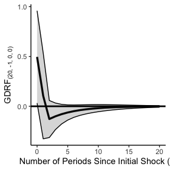

```r
GDRF.adl.plot(model = model.adl.diffs,
                                   x.vrbl = c("d_x" = 0, "l_1_d_x" = 1),
                                   y.vrbl = c("l_1_y" = 1),
                                   d.x = 1,
                                   d.y = 0,
                                   shock.history = "pulse",
                                   inferences.y = "levels",
                                   inferences.x = "levels",
                                   s.limit = 20,
                                   return.plot = TRUE)
```

(Notice the change in `d.x` and the `x.vrbl`). Suppose, though, that we wanted to apply this pulse to $x$ *in differences*. We just change the form of `inferences.x`, leaving all other arguments the same.

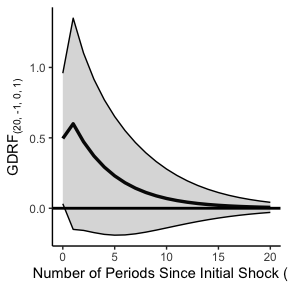

```r
GDRF.adl.plot(model = model.adl.diffs,
                                   x.vrbl = c("d_x" = 0, "l_1_d_x" = 1),
                                   y.vrbl = c("l_1_y" = 1),
                                   d.x = 1,
                                   d.y = 0,
                                   shock.history = "pulse",
                                   inferences.y = "levels",
                                   inferences.x = "differences",
                                   s.limit = 20,
                                   return.plot = TRUE)
```

The same changes could be made to `inferences.y` (if $y$ were modeled in differences). `d.x` should be entered as the form of the independent variable, even if the user desires the effects of a shock recovered in the differenced form (this should be handled by `inferences.x`). The same is true of `d.y`.

`GDRF.gecm.plot` is extremely similar. Imagine the following specified GECM model (with a first lag only of each $y$ and $x$ in levels)

```r
# Fit a GECM(1, 1)
model.gecm <- lm(d_y ~ l_1_y + l_1_d_y + l_1_x + d_x + l_1_d_x, data = toy.ts.interaction.data)
```

Since both the $x$ and $y$ variables appear in levels and differences, we need to differentiate them. `GDRF.gecm.plot` does this by separating them into two forms

- `x.vrbl`: a named vector of the x variables (of the lower level of differencing, usually in levels d = 0) and corresponding lag orders in the GECM model
- `y.vrbl`: a named vector of the (lagged) y variables (of the lower level of differencing, usually in levels d = 0) and corresponding lag orders in the GECM model
- `x.vrbl.d.x`: the order of differencing of the x variable (of the lower level of differencing, usually in levels d = 0) in the GECM model
- `y.vrbl.d.y`: the order of differencing of the y variable (of the lower level of differencing, usually in levels d = 0) in the GECM model
- `x.d.vrbl`: a named vector of the x variables (of the higher level of differencing, usually first differences d = 1) and corresponding lag orders in the GECM model
- `y.d.vrbl`: a named vector of the y variables (of the higher level of differencing, usually first differences d = 1) and corresponding lag orders in the GECM model
- `x.d.vrbl.d.x`: the order of differencing of the x variable (of the higher level of differencing, usually first differences d = 1) in the GECM model
- `y.d.vrbl.d.y`: the order of differencing of the y variable (of the higher level of differencing, usually first differences d = 1) in the GECM model

```r
gecm.pulse <- GDRF.gecm.plot(model = model.gecm,
                                   x.vrbl = c("l_1_x" = 1),
                                   y.vrbl = c("l_1_y" = 1),
                                   x.vrbl.d.x = 0,
                                   y.vrbl.d.y = 0,
                                   x.d.vrbl = c("d_x" = 0, "l_1_d_x" = 1),
                                   y.d.vrbl = c("l_1_d_y" = 1),
                                   x.d.vrbl.d.x = 1,
                                   y.d.vrbl.d.y = 1,
                                   shock.history = "pulse",
                                   inferences.y = "levels",
                                   inferences.x = "levels",
                                   s.limit = 20,
                                   return.plot = TRUE,
                                   return.formulae = TRUE)
```

Examining the formulae show that the conversion from GECM coefficients to ADL coefficients is automatic. As before, if we wanted a different shock history, we would just adjust `shock.history` to apply a different shock history to $x$ in levels.

# User-friendly conditional effects: `interact.adl.plot`

(Warner et al. 2026) advocate for a general model that allows for conditional dynamic relationships to unfold unrestricted over time. They demonstrate the superiority of this approach to a restricted model. It requires the estimation of a contmeporaneous interaction, cross-period interactions (i.e. $x_{t-1}$ and $z_t$ and vice versa), and lagged interactions (i.e. $x_{t-1}$ and $z_{t-1}$).

$$y_t = \alpha_0 +
\sum_{f=1}^p\alpha_{f}y_{t-f} + \sum_{g=0}^q \beta_{g}x_{t-g} +
\sum_{h=0}^q \theta_{h}z_{t-h} + \sum_{g=0}^q\sum_{h=0}^q \zeta_{g,
h}x_{t-g}z_{t-h} + \epsilon_t$$

They provide formulae for calculating effects, but no implementation of these formulae in software. Moreover, they do not explicitly recognize the conditional role of time itself ($s$, in our parlance) in moderating calculated interactive effects (see Jordan, Vande Kamp, and Rajan (2022) and Brambor, Clark, and Golder (**BramborClarkGolder2006?**)).

We resolve these deficiencies through `interact.adl.plot`. Many of the arguments are familiar

- `model`: a (well specified, etc.) ADL model, likely following the general recommendation of (Warner et al. 2026)
- `x.vrbl`: a named vector of the “main” $x$ variables and corresponding lag orders in the ADL model
- `z.vrbl`: a named vector of the “moderating” $z$ variables and corresponding lag orders in the ADL model
- `y.vrbl`: a named vector of the $y$ variable and its lag orders (if a lagged dependent variable is in the model)
- `x.z.vrbl`: a named vector with the interaction variables and corresponding lag orders in the ADL model

We pause to note something extremely important: `x.z.vrbl` should be constructed such that the lag orders reflect the lag order that pertains to the “main” $x$ variable. For instance, `x_l_1_z` (contemporaneous $x$ times lagged $z$) would be 0 and `z_l_1_x` (lagged $x$ times contemporaneous $z$) would be 1.

Four arguments pertain to how the interactive effect should be visualized (following Jordan, Vande Kamp, and Rajan (2022))

- `effect.type`: whether impulse or cumulative effects should be calculated. `impulse` generates impulse effects, or short-run/instantaneous effects specific to each period. `cumulative` generates the accumulated, or long-run/cumulative effects up to each period (including the long-run multiplier)
- `plot.type`: whether to feature marginal effects at discrete values of $s$/$z$ as lines, or across a range of values through a heatmap
- `line.options`: if drawing lines, whether the moderator should be values of $z$ or $s$
- `heatmap.options`: if drawing a heatmap, whether all marginal effects should be shown or just statistically significant ones

Users are encourgaed to experiment with many types of visualization: they all simply illustrate the underlying conditionality in the model. Aesthetics are generally presented with nice defaults, but options include

- `line.colors`: defaults to colorsafe Okabe-Ito colors, but any vector of colors (matching the number of lines) can be used (including a black and white graphic with `bw`)
- `heatmap.colors`: defaults to Blue-Red, but any `hcl.pal` is possible. We also create one for black and white graphics with `Grays`
- `z.label.rounding`: the number of digits to round $z$ to in a legend, if values are not discrete
- `z.vrbl.label`: the label to use for the $z$ variable in plots

A final set of controls involves the values of $z$ to calculate and plot across

- `z.vals`: if `plot.type = lines`, these are treated as discrete levels of $z$. If `plot.type = heatmap`, these are treated as a lower and upper level of a range of values of $z$
- `s.vals`: of `line.options = s.lines`, the values for the time since the shock. The default is 0 (short-run) and the `LRM`

All of these arguments have reasonable defaults. The arguments `dM.level`, `s.limit`, `se.type`, `return.data`, `return.plot`, and `return.formulae` are also available.

For a final time, let’s estimate a general model (just assuming it is well behaved)

```r
data(toy.ts.interaction.data)

# Fit an ADL(1, 1)
interact.model <- lm(y ~ l_1_y + x + l_1_x + z + l_1_z +
        x_z + z_l_1_x +
        x_l_1_z + l_1_x_l_1_z, data = toy.ts.interaction.data)
```

Let’s first illustrate a line type, where the moderation is shown a different values of $z$ over time. The shock history is a simple `effect.type = "impulse"`

```
interact.adl.plot(model = model.toydata, x.vrbl = c("x" = 0, "l_1_x" = 1),
                    y.vrbl = c("l_1_y" = 1),
                    z.vrbl = c("z" = 0, "l_1_z" = 1),
                    x.z.vrbl = c("x_z" = 0, "z_l_1_x" = 1, "x_l_1_z" = 0, "l_1_x_l_1_z" = 1),
                    z.vals = -1:1,
                    effect.type = "impulse", plot.type = "lines", line.options = "z.lines",
                    s.limit = 20)
```

If we wanted to moderate by $s$ instead

```
interact.adl.plot(model = model.toydata, x.vrbl = c("x" = 0, "l_1_x" = 1),
                    y.vrbl = c("l_1_y" = 1),
                    z.vrbl = c("z" = 0, "l_1_z" = 1),
                    x.z.vrbl = c("x_z" = 0, "z_l_1_x" = 1, "x_l_1_z" = 0, "l_1_x_l_1_z" = 1),
                    z.vals = -1:1,
                    s.vals = c(0, 5),
                    effect.type = "impulse", plot.type = "lines", line.options = "s.lines",
                    s.limit = 20)
```

```
interact.adl.plot(model = model.toydata, x.vrbl = c("x" = 0, "l_1_x" = 1),
                    y.vrbl = c("l_1_y" = 1),
                    z.vrbl = c("z" = 0, "l_1_z" = 1),
                    x.z.vrbl = c("x_z" = 0, "z_l_1_x" = 1, "x_l_1_z" = 0, "l_1_x_l_1_z" = 1),
                    z.vals = -1:1,
                    s.vals = c(0, 5),
                    effect.type = "step", plot.type = "lines", line.options = "s.lines",
                    s.limit = 20)
```

If we wanted to see the period-specific effects of $x$ across the full range of $z$, since it is continuous, the heatmap makes the most sense. Notice we omit `z.vals` this time to show that the function establishes reasonable defaults.

```
interact.adl.plot(model = model.toydata, x.vrbl = c("x" = 0, "l_1_x" = 1),
                    y.vrbl = c("l_1_y" = 1),
                    z.vrbl = c("z" = 0, "l_1_z" = 1),
                    x.z.vrbl = c("x_z" = 0, "z_l_1_x" = 1, "x_l_1_z" = 0, "l_1_x_l_1_z" = 1),
                    effect.type = "pulse", plot.type = "heatmap", heatmap.options = "all",
                    s.limit = 20)
```

If we want to ignore statistically insignificant effects, we can change the `heatmap.options` to be `significant`

```
interact.adl.plot(model = model.toydata, x.vrbl = c("x" = 0, "l_1_x" = 1),
                    y.vrbl = c("l_1_y" = 1),
                    z.vrbl = c("z" = 0, "l_1_z" = 1),
                    x.z.vrbl = c("x_z" = 0, "z_l_1_x" = 1, "x_l_1_z" = 0, "l_1_x_l_1_z" = 1),
                    effect.type = "pulse", plot.type = "heatmap", heatmap.options = "significant",
                    s.limit = 20)
```

# Concluding thoughts

A word of caution: `tseffects` is very naive to your model. This is true in three ways. First, it relies on the user to specify the lag structure correctly in both the underlying `lm` model as well as the corresponding plot you are producing. Including a term in the model, but not passing it to the plotting function (i.e. to `GDRF.adl.plot` through `x.vrbl`) will cause the calculation of the effects to be inaccurate. `interact.adl.plot` is completely uninformed about the underlying model: if there are interactive terms included in the model but not included in `interact.adl.plot`, the effect estimates will be incorrect. If a lagged variable is ommitted, the effect estimates will be incorrect. It is incumbent on the user to ensure that the model is well specified and that the specification is fully reflected in the interpretation function used.

Second, and to reiterate, it makes no check that your model is well specified. The best starting place for a calculation of effects is always a well-specified model; users should complete this before obtaining inferences. See the citations at the beginning of the vignette for places to start.

Third, it does not pass judgement on the shock history you are applying. Stationary (`d.x = 0`) variables cannot trend by definition, but specifying `shock.history = 1` in the function would apply a linear trend shock history anyway. This is not a good idea and is inconsistent with the underlying independent variable. However, shock histories are hypothetical, and we are loathe to limit the ability of a user to specify a counterfactual, consistent or not. We leave it in the user’s hands to determine if their shock is sensible or not.

Despite these words of caution, `tseffects` hopefully simplifies the job of the time series analyst in obtaining a variety of effects.

# Bibliography

Box, George E. P., Gwilym M. Jenkins, and Gregory C. Reinsel. 1994. *Time Seires Analysis: Forecasting and Control*. John Wiley; Sons.

De Boef, Suzanna, and Luke Keele. 2008. “Taking Time Seriously.” *American Journal of Political Science* 52 (1): 184–200. https://doi.org/10.1111/j.1540-5907.2007.00307.x.

Hendry, David E. 1995. *Dynamic Econometrics*. Oxford: Oxford University Press.

Jordan, Soren, and Andrew Q Philips. 2018a. “Cointegration Testing and Dynamic Simulations of Autoregressive Distributed Lag Models.” *The Stata Journal* 18 (4): 902–23.

Jordan, Soren, and Andrew Q. Philips. 2018b. “Dynamic Simulation and Testing for Single-Equation Cointegrating and Stationary Autoregressive Distributed Lag Models.” *The R Journal* 10 (42): 469–88.

Jordan, Soren, and Garrett N. Vande Kamp. 2022. “Modeling Dynamic Conditional Relationships Using Multiplicative Interactions in Dynamic Regression Model.” *Midwest Political Science Association Meeting* (Chicago, IL).

Kahle, David. 2013. “Mpoly: Multivariate Polynomials in R.” *The R Journal* 5 (1): 162–70. https://doi.org/10.32614/RJ-2013-015.

Philips, Andrew Q. 2022. “How to Avoid Incorrect Inferences (While Gaining Correct Ones) in Dynamic Models.” *Political Science Research and Methods*, no. 10: 879–89.

Pickup, Mark, and Paul M. Kellstedt. 2023. “Balance as a Pre-Estimation Test for Time Series Analysis.” *Political Analysis* 2 (31): 295–304.

Vande Kamp, Garrett N., and Soren Jordan. 2025. “The Necessity of Moving Averages in Dynamic Linear Regression Models.” *American Journal of Political Science* 1 (69): 176–93.

Vande Kamp, Garrett N., Soren Jordan, and Reshi Rajan. 2025. “Causal Inference for Integrated Data Using Differenced Variables.” *Annual Meeting of the Society for Political Methodology* (Atlanta, GA).

Warner, Zach, Garrett N. Vande Kamp, and Soren Jordan. 2026. “Conditional Relationships in Dynamic Models.” *Political Science Research and Methods*, 1–20. https://doi.org/10.1017/psrm.2026.10087.

Wilkins, Arjun S. 2018. “To Lag or Not to Lag?: Re-Evaluating the Use of Lagged Dependent Variables in Regression Analysis.” *Political Science Research and Methods* 6 (2): 393–411.